# Assessing Epidemiological Level of Risk (ELR)

# 2 Generate pre-classification

## 2.1 Classification algorithm

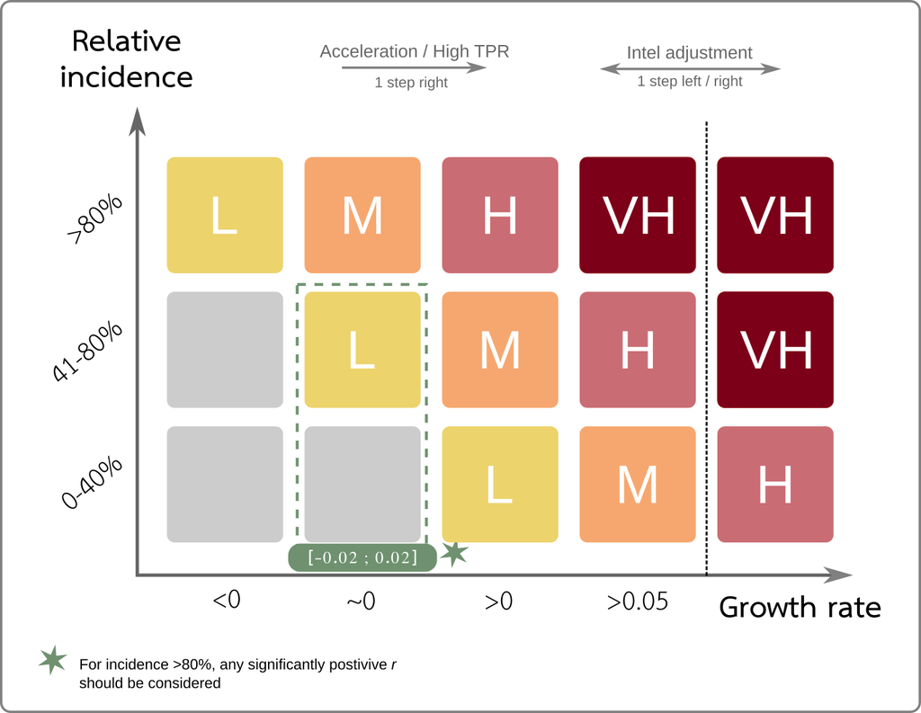

We define the following classes for levels of concerns:

We use the following classification rules, depending on the values of the growth rate (*r*), current incidence (as % of previous peak) and signs of acceleration (ASMODEE net increases over last week):

- if incid < 40%:
  - if r > high_r -> **M**
  - else if r > 0.02 -> **L**
  - else -> Minimal
- if 40% <= incid <= 80%:
  - if r > high_r -> **H**
  - else if r > 0.02 -> **M**
  - else if r is not < 0 -> **L**
  - else -> **Minimal**
- if incid > 80%:
  - if r > high_r -> **VH**
  - else if r > 0 -> **H**
  - else if r is not < 0 -> **M**
  - else -> **L**
- if acceleration, upgrade by 1 step (bound at **VH**)

with by default, *high_r* = 0.05, and at least 3 days of net increase to register as a sign of acceleration.

```r
make_classif <- function(incid, r, r_lower, r_upper, accel,
                         high_r = 0.05,
                         r_limit = 0.02,
                         n_accel = 3,
                         incid_tiers = c(0.4, 0.8)) {

  # The output will be stored as numbers first and converted at the end:
  ## 0 = Minimal
  ## 1 = low
  ## 2 = mid
  ## 3 = high
  ## 4 = very high

  incid_tiers <- sort(incid_tiers)

  if (is.na(incid) | is.na(r) | is.na(accel)) return(NA_character_)

  ## incid 0-40%
  if (incid < incid_tiers[1]) {
    if (r_lower > high_r) {
      out <- 2
    } else if (r_lower > r_limit) {
      out <- 1
    } else {
      out <- 0
    }
  } else if (incid <= incid_tiers[2]) {
      ## incid 40-80%
      if (r_lower > high_r) {
        out <- 3
      } else if (r_lower > r_limit) {
        out <- 2
      } else if (r_lower > -r_limit) {
        out <- 1
      } else {
        out <- 0
      }
  } else {
    ## incid >80%
    if (r_lower > high_r) {
        out <- 4
      } else if (r_lower > 0) {
        out <- 3
      } else if (r_upper > 0) {
        out <- 2
      } else {
        out <- 1
      }
  }

  ## add +1 if acceleration
  if (accel >= n_accel & out < 4) {
    out <- out + 1
  }

  c("Minimal", "Low", "Medium", "High", "Very High")[out + 1]
}


## apply classification algo to countries
x <- x %>%
  group_by(iso3) %>%
  mutate(
    classif = make_classif(incid = perc_peak,
                           r = r, r_lower = r_lower, r_upper = r_upper,
                           accel = net_increases),
    classif = factor(classif, levels =  c("Minimal", "Low", "Medium", "High", "Very High"))
  )

## add TPR info
x <- x %>%
  left_join(select(all_elr_extras, -who_region), by = "iso3")

## add classification to x_all
x_all <- x_all %>%
  left_join(x %>% select(iso3, classif), by = "iso3")
```

## 2.2 Leaderboard table

We reformat the results into `out` and print the table with Low levels and above:

```r
out <- x %>%
  arrange(desc(as.integer(classif))) %>%
  select(report_country, iso3,
         classif,
         r, r_lower, r_upper,
         perc_peak, net_increases,
         tpr_recent, tpr_before, tpr_change) %>%
  mutate(r = round(r, 3),
         r_lower = round(r_lower, 3),
         r_upper = round(r_upper, 3),
         perc_peak = round(perc_peak, 3),
         tpr_recent = round(tpr_recent, 3),
         tpr_before = round(tpr_before, 3)
         )

out %>%
  ungroup() %>%
  mutate(
    perc_peak = paste(round(100 * perc_peak), "%"),
    tpr_recent = if_else(is.na(tpr_recent),
                         "",
                         paste(round(100 * tpr_recent), "%")),
    tpr_before = if_else(is.na(tpr_before),
                         "",
                         paste(round(100 * tpr_before), "%"))) %>%
  rename(Country = report_country,
         "% peak" = perc_peak,
         ELR = classif,
         ) %>%
  select(-iso3) %>%
  filter(ELR != "Minimal") %>%
  DT::datatable(rownames = FALSE, options = list(pageLength = nrow(.)))
```

| Country | ELR | r | r_lower | r_upper | % peak | net_increases | tpr_recent | tpr_before | tpr_change |
| --- | --- | --- | --- | --- | --- | --- | --- | --- | --- |
| Congo | Very High | 0.1 | 0.086 | 0.115 | 57 % | 3 |  |  |  |
| United Republic of Tanzania | Very High | 0.211 | 0.208 | 0.214 | 4785 % | 1 |  |  |  |
| Syrian Arab Republic | Very High | 0.068 | 0.063 | 0.073 | 217 % | 5 |  |  |  |
| Saint Vincent and the Grenadines | Very High | 0.073 | 0.061 | 0.085 | 100 % | 0 |  |  |  |
| Brunei Darussalam | Very High | 0.044 | 0.038 | 0.049 | 123 % | 5 | 3 % | 4 % | decreasing |
| New Caledonia | Very High | 0.06 | 0.056 | 0.064 | 91 % | 0 |  |  |  |
| Singapore | Very High | 0.084 | 0.082 | 0.087 | 143 % | 0 | 0 % | 0 % | constant |
| Angola | High | 0.022 | 0.018 | 0.026 | 119 % | 0 | 5 % | 7 % | decreasing |
| Gabon | High | 0.021 | 0.015 | 0.026 | 103 % | 2 | 5 % | 4 % | increasing |
| Sao Tome and Principe | High | 0.028 | 0.016 | 0.04 | 89 % | 0 |  |  |  |

[output cut: 66 more lines]

## 2.3 Pinplot

These pinplots shows all countries classified as ‘Medium’ and above.

### 2.3.1 By % incidence peak

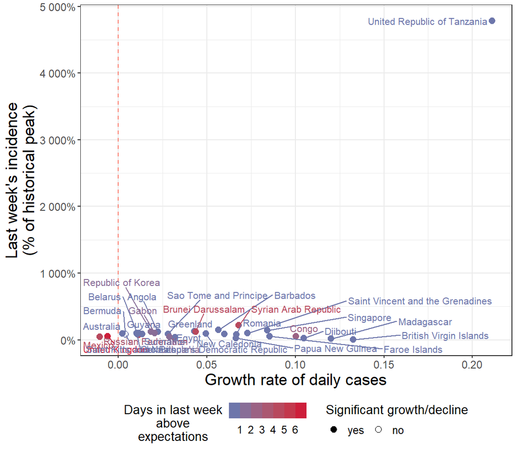

```r
scale_signif <- scale_shape_manual(
  "Significant growth/decline",
  values = c(yes = 19, no = 1)
)

scale_asmodee <- scale_colour_steps(
  "Days in last week\nabove\nexpectations",
  low = "#5b7bb5",
  high = "#d10031",
  breaks = 0:7,
  limits = c(0,7))


plot_overall_peaks <- x %>%
  filter(classif %in% c("Medium", "High", "Very High")) %>%
  ggplot(aes(x = r, y = perc_peak, color = net_increases)) +
  theme_bw() +
  geom_vline(xintercept = 0, linetype = 2, color = "salmon") +
  geom_point(aes(shape = r_signif), size = 3) +
  geom_text_repel(
    aes(label = report_country), max.overlaps = 100,
                  max.time = 2, max.iter = 1e5) +
  scale_y_continuous(labels = scales::percent) +
  scale_signif +
  scale_asmodee +
  labs(x = "Growth rate of daily cases",
       y = "Last week's incidence\n(% of historical peak)") +
  theme(legend.position = "bottom",
        axis.text = element_text(size = 12),
        axis.title = element_text(size = 18),
        plot.subtitle = element_text(size = 12),
        legend.text = element_text(size = 12),
        legend.title = element_text(size = 14),
        legend.title.align = 0.5) +
  guides(
    color = guide_colorsteps(order = 1),
    shape = guide_legend(title.position = "top", order = 2))

plot_overall_peaks
```

### 2.3.2 By deaths per capita

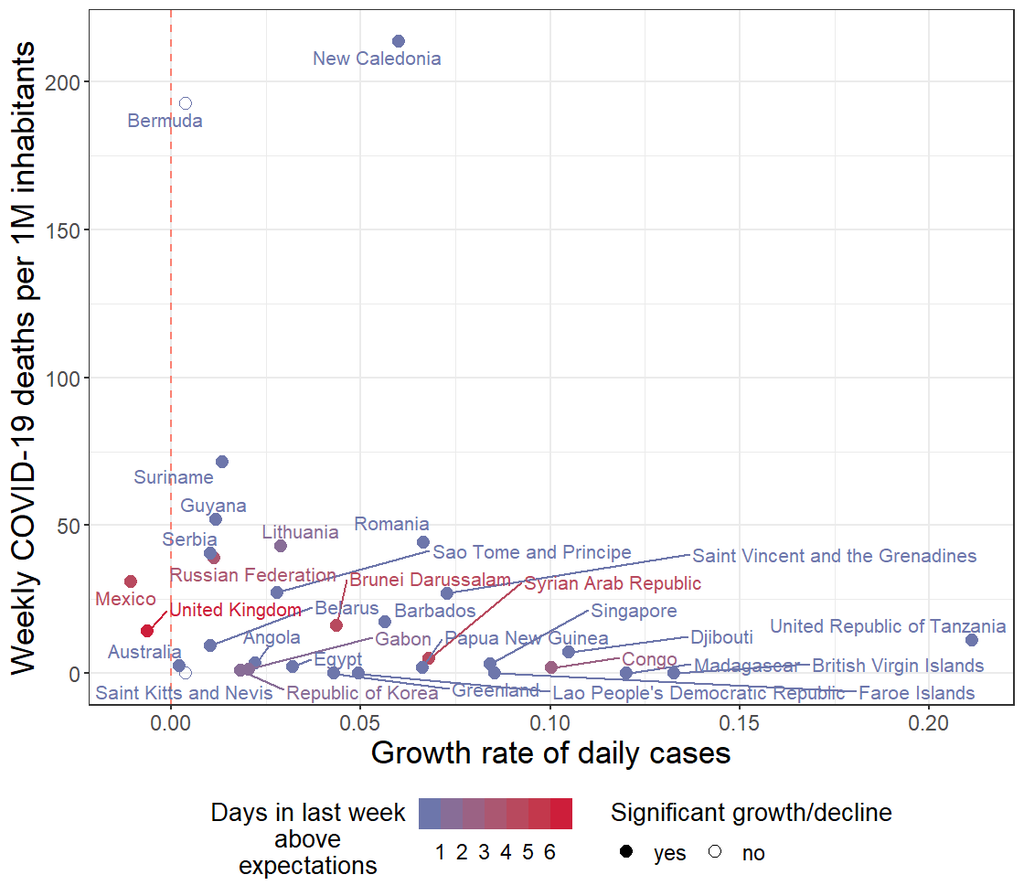

```r
# tadpole plot
plot_overall_deaths <- x %>%
  filter(classif %in% c("Medium", "High", "Very High")) %>%
  ggplot(aes(x = r, y = death_incid_last_week, color = net_increases)) +
  theme_bw() +
  geom_vline(xintercept = 0, linetype = 2, color = "salmon") +
  geom_point(aes(shape = r_signif), size = 3) +
  geom_text_repel(
    aes(label = report_country), max.overlaps = 100,
                  max.time = 2, max.iter = 1e5) +
  scale_signif +
  scale_asmodee +
  labs(x = "Growth rate of daily cases",
       y = "Weekly COVID-19 deaths per 1M inhabitants") +
  theme(legend.position = "bottom",
        axis.text = element_text(size = 12),
        axis.title = element_text(size = 18),
        plot.subtitle = element_text(size = 12),
        legend.text = element_text(size = 12),
        legend.title = element_text(size = 14),
        legend.title.align = 0.5) +
  guides(
    color = guide_colorsteps(order = 1),
    shape = guide_legend(title.position = "top", order = 2))

plot_overall_deaths
```

## 2.4 Tadpoles

### 2.4.1 By % incidence peak

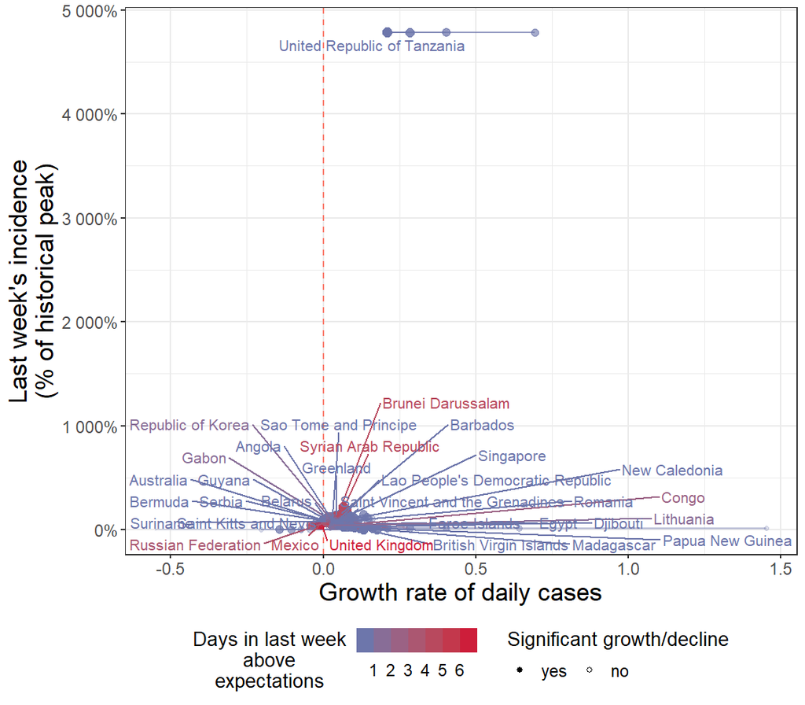

```r
plot_tadpole_peaks <- x_all %>%
  filter(classif %in% c("Medium", "High", "Very High")) %>%
  group_by(report_country) %>%
  arrange(last_day) %>%
  ggplot(aes(x = r, y = perc_peak, color = net_increases)) +
  theme_bw() +
  geom_vline(xintercept = 0, linetype = 2, color = "salmon") +
  geom_path(aes(group = report_country, alpha = last_day)) +
  geom_point(aes(size = last_day, alpha = last_day, shape = r_signif)) +
  geom_text_repel(
    data = filter(x, classif %in% c("Medium", "High", "Very High")),
    aes(label = report_country), max.overlaps = 100,
                  max.time = 2, max.iter = 1e5) +
  scale_y_continuous(labels = scales::percent) +
  scale_signif +
  scale_asmodee +
  scale_alpha_continuous(trans = "reverse") +
  scale_size_continuous(range = c(0.5, 3), trans = "reverse") +
  labs(x = "Growth rate of daily cases",
       y = "Last week's incidence\n(% of historical peak)") +
  theme(legend.position = "bottom",
        axis.text = element_text(size = 12),
        axis.title = element_text(size = 18),
        plot.subtitle = element_text(size = 12),
        legend.text = element_text(size = 12),
        legend.title = element_text(size = 14),
        legend.title.align = 0.5) +
  guides(
    color = guide_colorsteps(order = 1),
    shape = guide_legend(title.position = "top", order = 2),
    size = "none",
    alpha = "none")

plot_tadpole_peaks
```

### 2.4.2 By deaths per capita

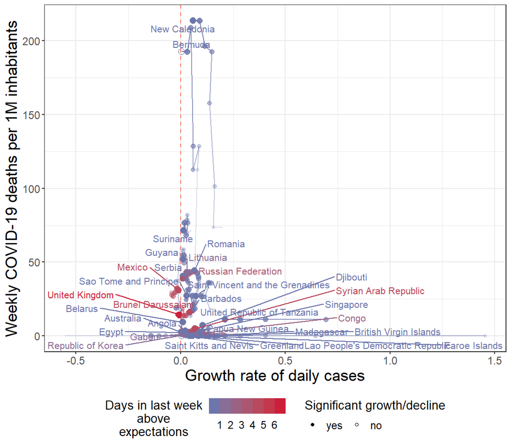

```r
# tadpole plot
plot_tadpole_deaths <- x_all %>%
  filter(classif %in% c("Medium", "High", "Very High")) %>%
  group_by(report_country) %>%
  arrange(last_day) %>%
  ggplot(aes(x = r, y = death_incid_last_week, color = net_increases)) +
  theme_bw() +
  geom_vline(xintercept = 0, linetype = 2, color = "salmon") +
  geom_path(aes(group = report_country, alpha = last_day)) +
  geom_point(aes(size = last_day, alpha = last_day, shape = r_signif)) +
  geom_text_repel(
    data = filter(x, classif %in% c("Medium", "High", "Very High")),
    aes(label = report_country), max.overlaps = 100,
                  max.time = 2, max.iter = 1e5) +
  scale_signif +
  scale_asmodee +
  scale_alpha_continuous(trans = "reverse") +
  scale_size_continuous(range = c(0.5, 3), trans = "reverse") +
  labs(x = "Growth rate of daily cases",
       y = "Weekly COVID-19 deaths per 1M inhabitants") +
  theme(legend.position = "bottom",
        axis.text = element_text(size = 12),
        axis.title = element_text(size = 18),
        plot.subtitle = element_text(size = 12),
        legend.text = element_text(size = 12),
        legend.title = element_text(size = 14),
        legend.title.align = 0.5) +
  guides(
    color = guide_colorsteps(order = 1),
    shape = guide_legend(title.position = "top", order = 2),
    size = "none",
    alpha = "none")

plot_tadpole_deaths
```

## 2.5 ASMODEE plots

We provide ASMODEE plots for countries classified as “Medium” and above.

```r
to_keep <- x %>%
  filter(classif %in% c("Medium", "High", "Very High")) %>%
  pull(report_country)

asmodee_res <- map(all_content, list("results")) %>%
  bind_rows() %>%
  filter(report_country %in% to_keep) %>%
  arrange(report_country)

n_plots <- nrow(asmodee_res)
```

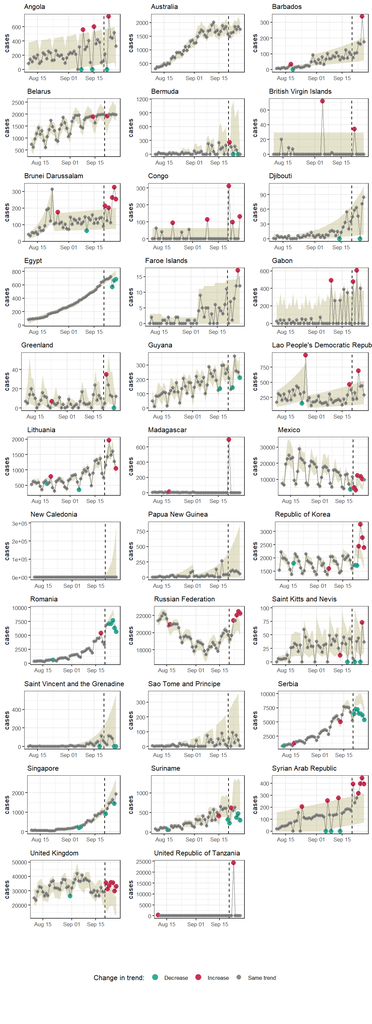

```r
plot(asmodee_res, ncol = 3)
```

```r
## re-arrange data into wide format, filter relevant stuff
voi <- dat_voi %>%
  filter(report_country %in% to_keep,
         date >= (Sys.Date() - 7*4),
         date < Sys.Date()) %>%
  arrange(report_country)

## re-order variants
voi <- voi %>%
  mutate(variant = factor(variant),
         variant = forcats::fct_relevel(variant, "Other", after = Inf))
```

```r
n_plots <- length(unique(voi$report_country))
```

# 3 Export table

## 3.1 Add extra info

We add the following info to the output table:

- Monday of the reporting week
- country info (WHO region, iso3 and population size)

We also renamed columns for compatibility with the decision spreadsheets:

```r
# load country info
df_countries <- load_countries_data()
# remove redundant country info in out
out <- out %>%
  ungroup() %>%
  select(-report_country)

# add country info and order table
out_full <- df_countries %>%
  left_join(out, by = "iso3") %>%
  arrange(who_region, report_country)

## add date and rename/reorder columns
out_final <- out_full %>%
  mutate(assessment_week_begins = Sys.Date() %>%
           grates::as_yearweek() %>%
           as.Date()) %>%
  select(
    assessment_date = assessment_week_begins,
    country = report_country,
    iso3,
    region = who_region,
    population = population,
    growth_rate = r,
    relative_incidence = perc_peak,
    net_increases = net_increases,
    epi_classification = classif,
    growth_rate_lower = r_lower,
    growth_rate_upper = r_upper
  ) %>%
     mutate(relative_incidence = scales::percent(relative_incidence, accuracy = 0.1))

# join to vaccine coverage/tpr data
elr_extra_to_keep <- all_elr_extras %>%
  select(
    iso3,
    tpr_recent,
    tpr_before,
    tpr_change,
    tpr_last_date_recent,
    tpr_last_date_before,
    vac_oneplus_dose_per_100,
    vac_full_per_100,                      # percent fully vaccinated
    vaccinations_date = as_of_vaccine
         ) %>%
  mutate(
    tpr_recent = scales::percent(tpr_recent, accuracy = 0.1),
    tpr_before = scales::percent(tpr_before, accuracy = 0.1),
    vac_oneplus_dose_per_100 = round(vac_oneplus_dose_per_100, digits = 1),
    vac_full_per_100 = round(vac_full_per_100, digits = 1))

out_final <- out_final %>%
     left_join(elr_extra_to_keep, by = "iso3")
```

```r
## export asmodee summary
write_csv(out_final, here::here("dynamics_outputs/csv/dynamics_synthesis.csv"), na = "")

## export asmodee summary (dated)
rio::export(out_final, file = here::here(paste0("dynamics_outputs/csv/dynamics_synthesis_", Sys.Date(), ".csv")))
```

# 4 Export notes

## 4.1 Compile all notes

We read all the latest notes and compile them into a single character vector:

```r
# get file locations
file_paths <- here::here("asmodee_outputs", "notes") %>%
  list.files(pattern = "latest", full.names = TRUE)

# get corresponding regions
file_names <- here::here("asmodee_outputs", "notes") %>%
  list.files(pattern = "latest")
regions <- gsub("[^A-Z]", "", file_names)

# read notes
all_notes <- file_paths %>%
  map(readLines)

# concatenate notes
notes <- lapply(all_notes, function(e) e[1]) %>% unlist()
notes <- paste(regions, "----", notes, "\n", sep = "\n")
notes <- gsub("<br>", "\n", notes)
```

```r
## export notes to file
writeLines(notes, here::here("dynamics_outputs/notes/excluded_countries.txt"))

## export notes to file
writeLines(notes, here::here(paste0("dynamics_outputs/notes/excluded_countries_", Sys.Date(), ".txt")))
```